# Ekz

Yulian Volianskiy

06 01 2021

1. Reading data and transform Date from char to Date format

```r
library(lubridate)
```

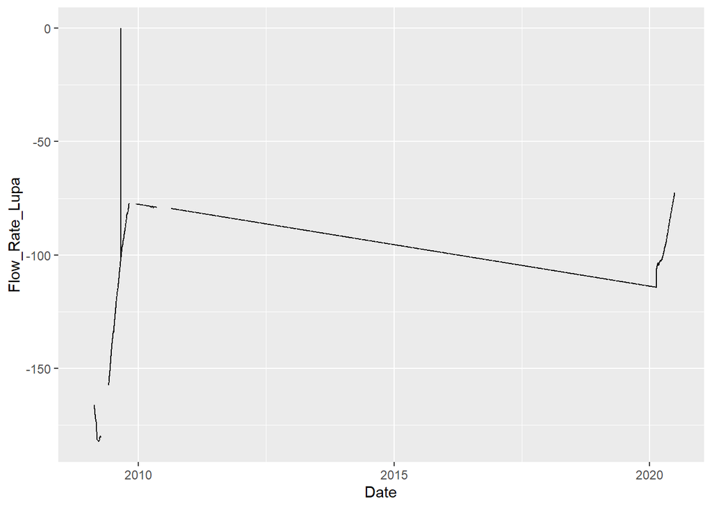

```r
library(ggplot2)

setwd("E:/prazia/univer/DataScience/Ekz/acea-water-prediction")
df <- read.csv("Water_Spring_Lupa.csv")
df$п.їDate = strptime(df$п.їDate, "%d/%m/%Y")
df$Date <- ymd(df$п.їDate)
ggplot(data=df, aes(x=Date, y=Flow_Rate_Lupa)) + geom_line()
```

```r
head(df)
```

```
##      п.їDate Rainfall_Terni Flow_Rate_Lupa       Date
## 1 2009-01-01          2.797             NA 2009-01-01
## 2 2009-01-02          2.797             NA 2009-01-02
## 3 2009-01-03          2.797             NA 2009-01-03
## 4 2009-01-04          2.797             NA 2009-01-04
## 5 2009-01-05          2.797             NA 2009-01-05
## 6 2009-01-06          2.797             NA 2009-01-06
```

```r
df_data <- read.csv("water_spring_lupa_csv_r2.csv")
head(df_data)
```

```
##      п.їDate rainfall_terni flow_rate_lupa
## 1 01/01/2009          2.797             NA
## 2 02/01/2009          2.797             NA
## 3 03/01/2009          2.797             NA
## 4 04/01/2009          2.797             NA
## 5 05/01/2009          2.797             NA
## 6 06/01/2009          2.797             NA
```

```r
df_train <- read.csv("water_spring_lupa_csv_r.csv")
head(df_data)
```

```
##      п.їDate rainfall_terni flow_rate_lupa
## 1 01/01/2009          2.797             NA
## 2 02/01/2009          2.797             NA
## 3 03/01/2009          2.797             NA
## 4 04/01/2009          2.797             NA
## 5 05/01/2009          2.797             NA
## 6 06/01/2009          2.797             NA
```

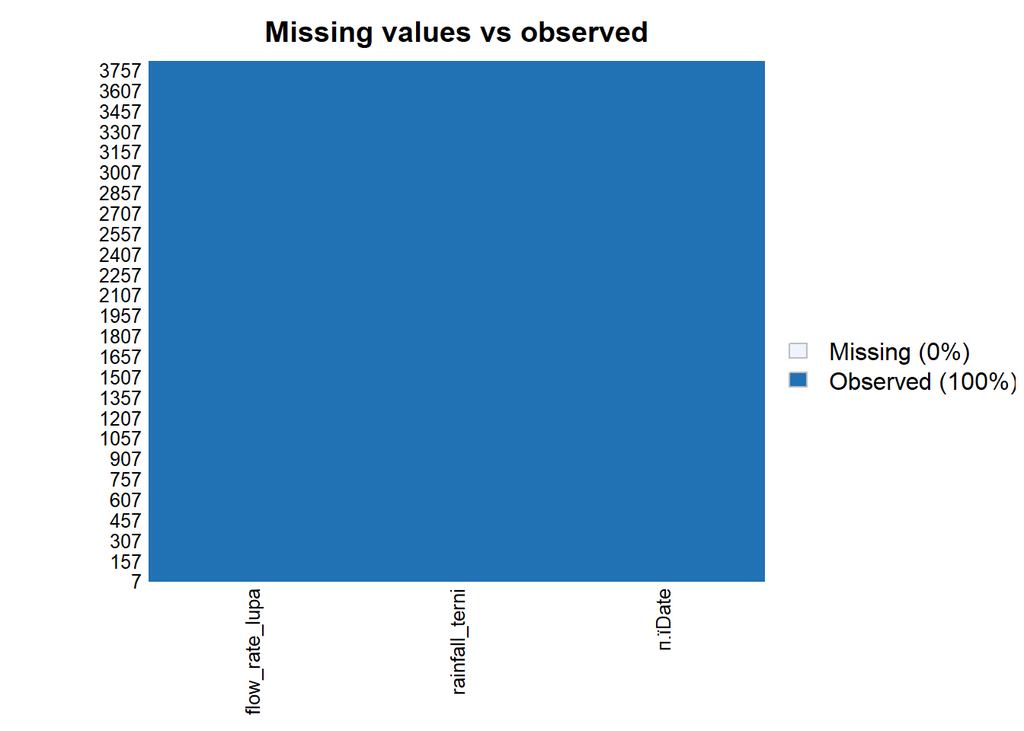

```r
library(Amelia)
missmap(df_train, main = "Missing values vs observed")
```

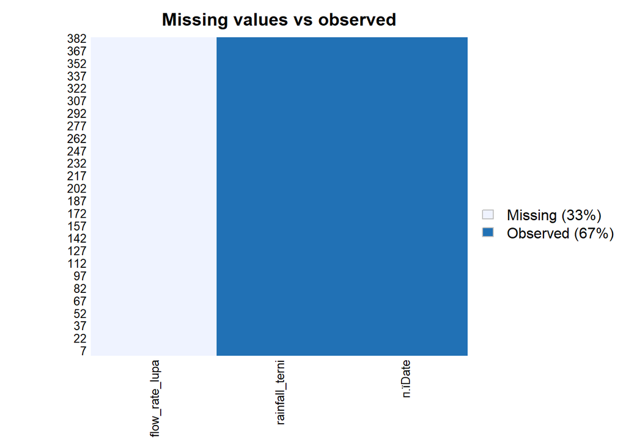

```r
missmap(df_data, main = "Missing values vs observed")
```

```r
train1 <- head(df_train, 3000)
test1 <- tail(df_train, 817)
```

Here we can see a plot, that shows us an empty parts in our data. So first of all we should to find Nans and predict them. I divided data in two types: 1. Data with Nans 2. Data without empty fields

After that I divided data without empty fields into train and test datas. It will be useful for linear regresion model.

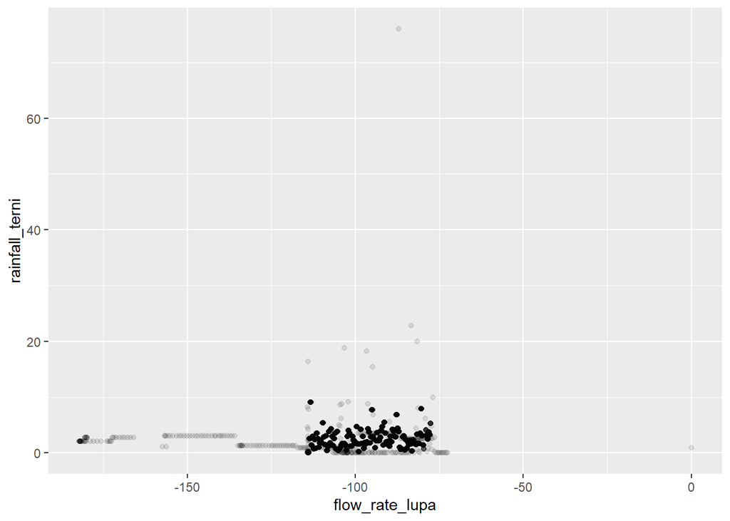

```r
library(ggplot2)
library(hexbin)

ggplot(df_train, aes(x = flow_rate_lupa, y = rainfall_terni)) + geom_point(alpha = 0.1)
```

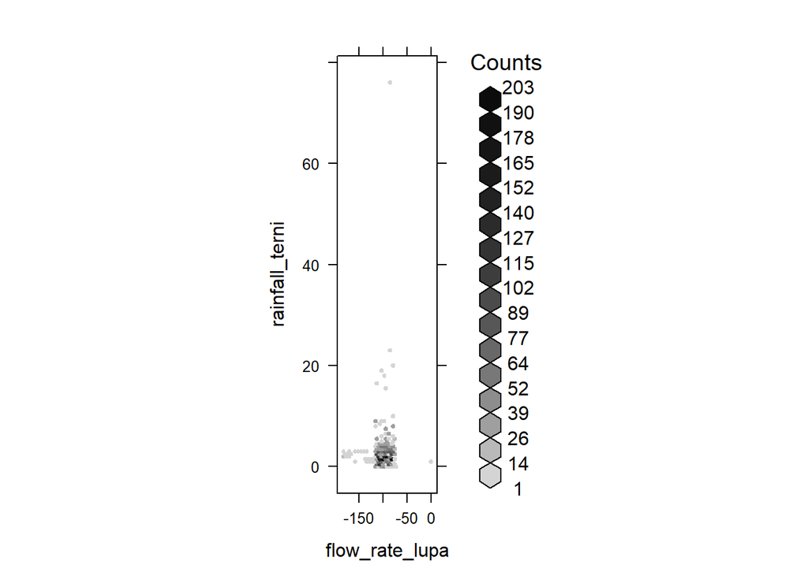

```r
hexbinplot(rainfall_terni ~ flow_rate_lupa, data=df_train)
```

```r
df_trainLM = lm(flow_rate_lupa ~ rainfall_terni, data = df_train) #Create the linear regression
summary(df_trainLM)
```

```
##
## Call:
## lm(formula = flow_rate_lupa ~ rainfall_terni, data = df_train)
##
## Residuals:
##     Min      1Q  Median      3Q     Max
## -84.419  -8.286   0.953   9.895  98.398
##
## Coefficients:
##                Estimate Std. Error  t value Pr(>|t|)
## (Intercept)    -98.8265     0.3748 -263.649  < 2e-16 ***
## rainfall_terni   0.4508     0.1156    3.899 9.83e-05 ***
## ---
## Signif. codes:  0 '***' 0.001 '**' 0.01 '*' 0.05 '.' 0.1 ' ' 1
##
## Residual standard error: 15 on 3815 degrees of freedom
## Multiple R-squared:  0.003969,   Adjusted R-squared:  0.003708
## F-statistic:  15.2 on 1 and 3815 DF,  p-value: 9.828e-05
```

Using prediction function we try to predict values in empty fields

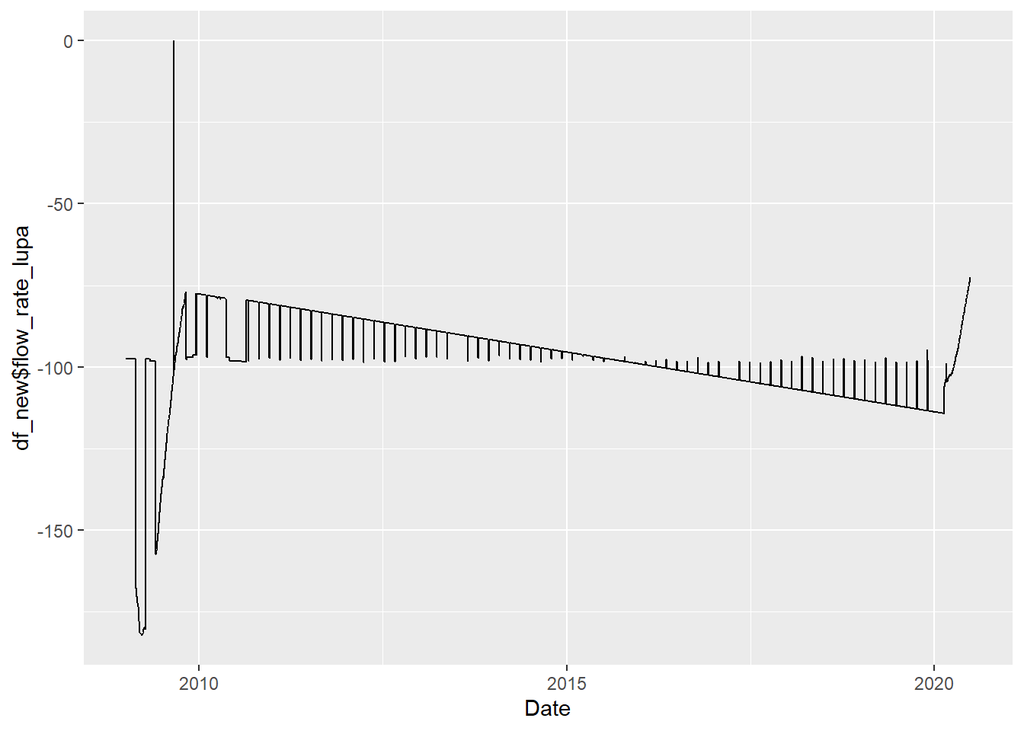

```r
newdata1 <- test1$flow_rate_lupa
df_data$flow_rate_lupa <-predict(df_trainLM,newdata=df_data,type="response")
df_new <- rbind(df_data,df_train)

df_new$п.їDate = strptime(df_new$п.їDate, "%d/%m/%Y")
df_new$Date <- ymd(df_new$п.їDate)

ggplot(data=df_new, aes(x=Date, y=df_new$flow_rate_lupa)) + geom_line()
```

In the plot we can see that it hasn’t even distribution, so that kind of prediction data doesn’t fit.

Another way to predict data - using interpolation function, so lets try it:

```r
library(imputeTS)
library(lubridate)
df$Flow_Rate_Lupa <- na.interpolation(df$Flow_Rate_Lupa, option = "spline")
```

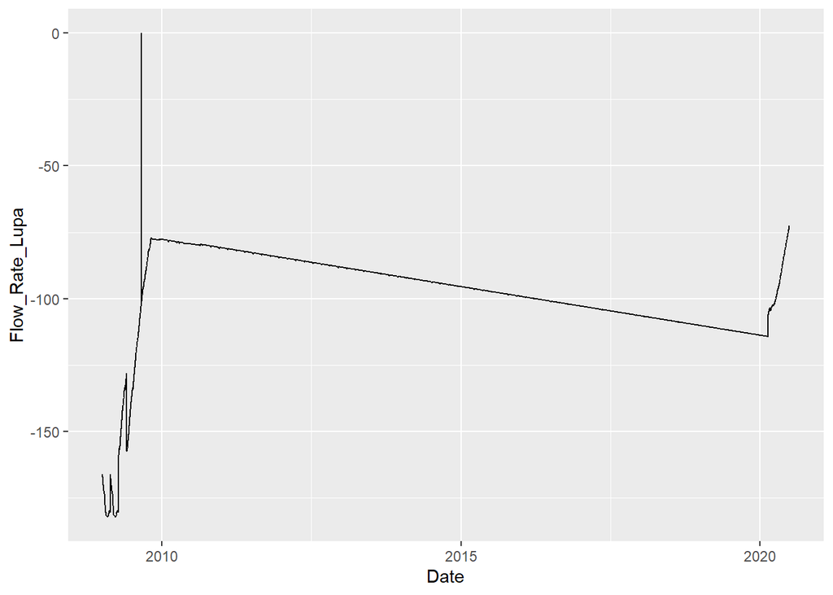

```r
df$Date <- ymd(df$п.їDate)

library(ggplot2)

ggplot(data=df, aes(x=Date, y=Flow_Rate_Lupa)) + geom_line()
```

```r
#plot(x=df$п.їDate, y=df$Flow_Rate_Lupa)
```

In the plot we can see, that it probably fits our problem and have even distribution in empty places.

Prepare data and sort by date. Check timeinterval.

```r
library(data.table)
df <- df[order(df$Date), ]
df['Time_Interval'] = df$Date - shift(df$Date, n=1, fill=NA, type="lag")

days <- df$Time_Interval


for(i in days)
{

  if(isTRUE(i > 1) || is.null(i))
  {
    print(i)
  }

}
```

```r
myts <- ts(df$Flow_Rate_Lupa, start=c(2009, 1, 1), end=c(2020, 30, 6), frequency=52)
```

#Augmented Dickey-Fuller (ADF)

If the null hypothesis can be rejected, we can conclude that the time series is stationary.

There are two ways to rejects the null hypothesis:

On the one hand, the null hypothesis can be rejected if the p-value is below a set significance level. The defaults significance level is 5%

**p-value > significance level (default: 0.05)**: Fail to reject the null hypothesis (H0), the data has a unit root and is non-stationary. **p-value <= significance level (default: 0.05)**: Reject the null hypothesis (H0), the data does not have a unit root and is stationary. On the other hand, the null hypothesis can be rejects if the test statistic is less than the critical value.

```r
library(tseries)
result4 = adf.test(myts)
result4
```

```
##
##  Augmented Dickey-Fuller Test
##
## data:  myts
## Dickey-Fuller = -0.70215, Lag order = 8, p-value = 0.9703
## alternative hypothesis: stationary
```

As we can see from previous test, p_value > 0.05, so we should do transformation and differencing:

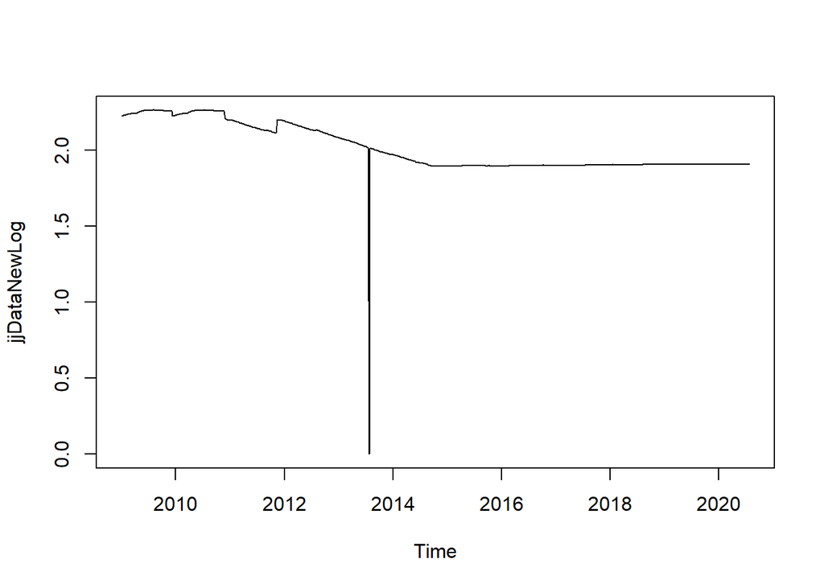

```r
#myts

jjDataNewLog <- log10(abs(myts) + 1)
#jjDataNewLogDiff <- diff(jjDataNewLog)
#jjDataNewLogDiff <- na_interpolation(jjDataNewLogDiff, option = "linear")
plot(jjDataNewLog)
```

After this, try again a test:

```r
result4 = adf.test(jjDataNewLog)
result4
```

```
##
##  Augmented Dickey-Fuller Test
##
## data:  jjDataNewLog
## Dickey-Fuller = -2.8961, Lag order = 8, p-value = 0.199
## alternative hypothesis: stationary
```

```r
jjDataNewLog <- sqrt(jjDataNewLog)
result4 = adf.test(jjDataNewLog)
result4
```

```
##
##  Augmented Dickey-Fuller Test
##
## data:  jjDataNewLog
## Dickey-Fuller = -4.9424, Lag order = 8, p-value = 0.01
## alternative hypothesis: stationary
```

We see that p_value is normal, so let’s use this data

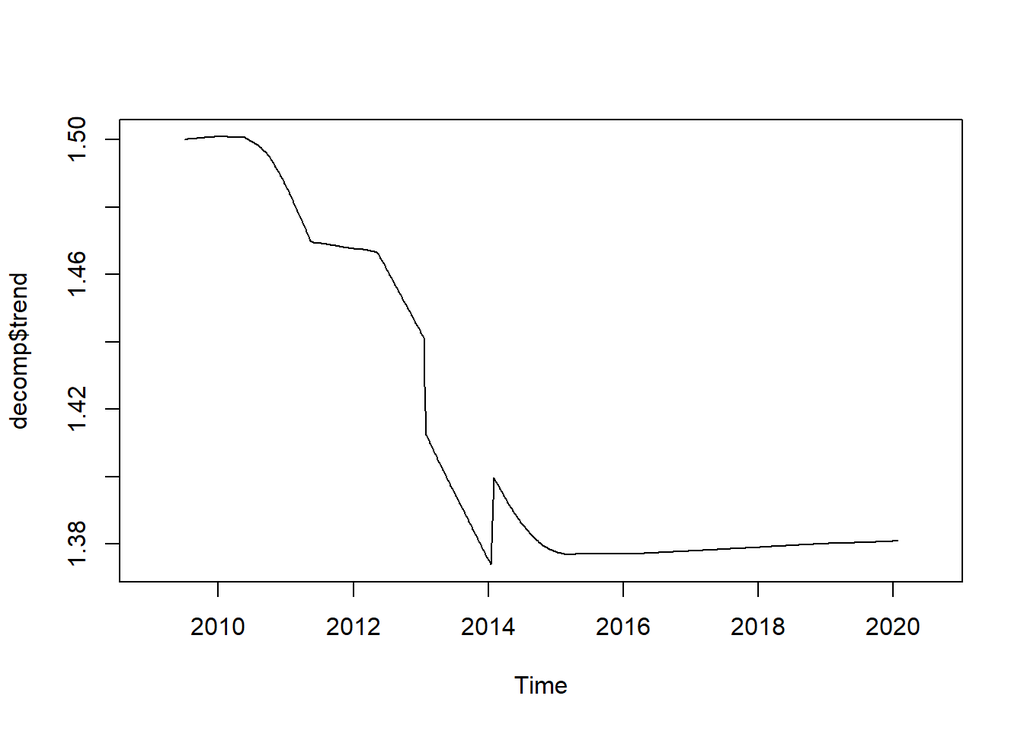

```r
decomp = decompose(jjDataNewLog, type='additive')

plot(decomp$trend)
```

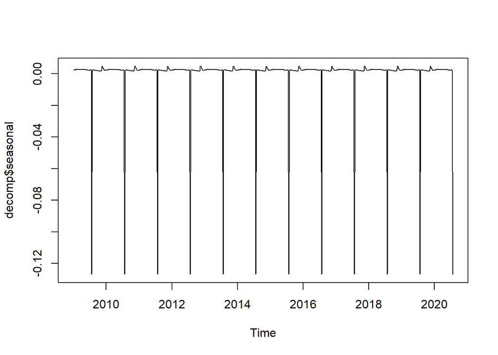

```r
plot(decomp$seasonal)
```

Split our data in train and test and try acf and pacf test for our data:

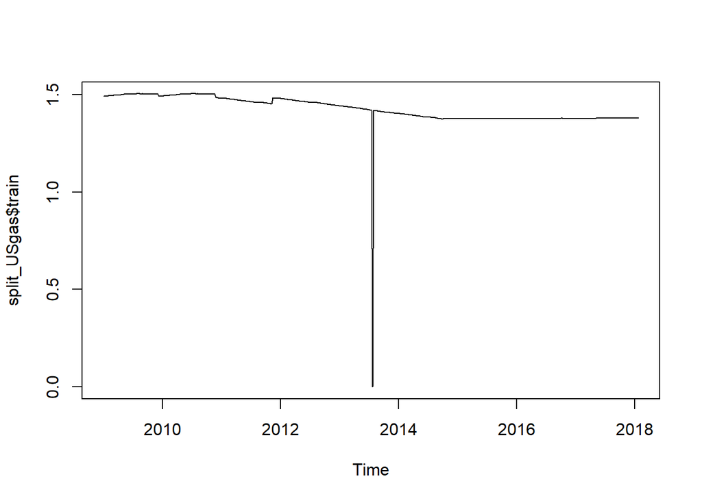

```r
library(TSstudio)

split_USgas <- ts_split(ts.obj = jjDataNewLog, 130)

plot(split_USgas$train)
```

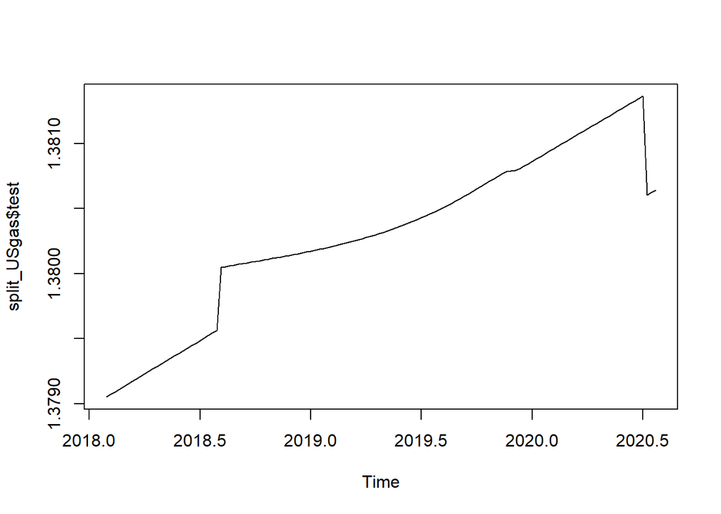

```r
plot(split_USgas$test)
```

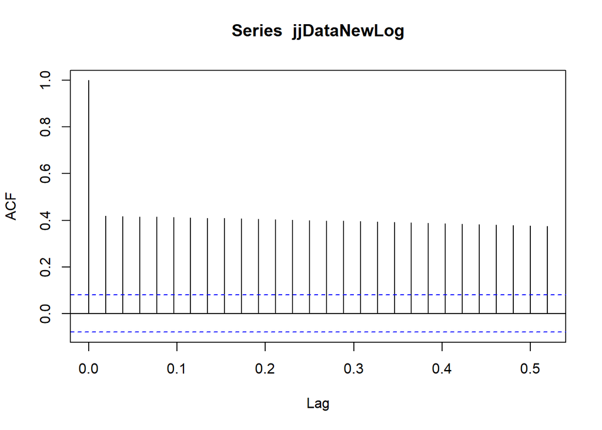

```r
acf(jjDataNewLog)
```

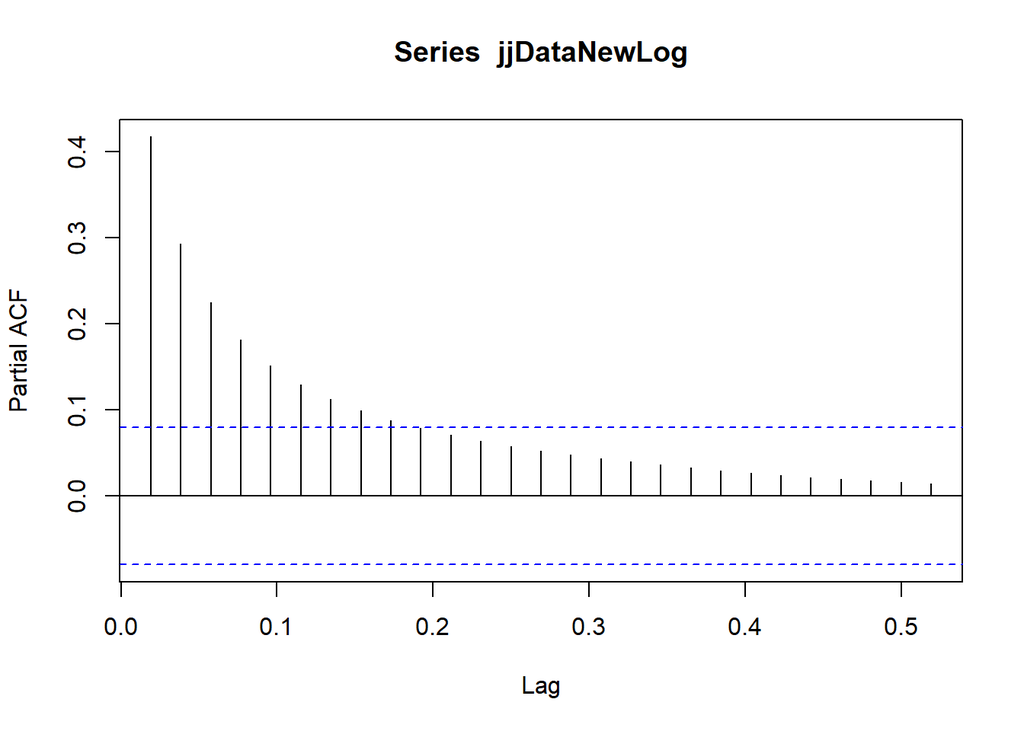

```r
pacf(jjDataNewLog)
```

Using coefficients (1,1,8) for ARIMA we will test it.

```r
library(forecast)

auto.arima(split_USgas$train, trace=TRUE)
```

```
##
##  Fitting models using approximations to speed things up...
##
##  ARIMA(2,1,2)(1,0,1)[52] with drift         : -1137.185
##  ARIMA(0,1,0)            with drift         : -897.027
##  ARIMA(1,1,0)(1,0,0)[52] with drift         : -972.1638
##  ARIMA(0,1,1)(0,0,1)[52] with drift         : -1201.452
##  ARIMA(0,1,0)                               : -899.041
##  ARIMA(0,1,1)            with drift         : -1203.485
##  ARIMA(0,1,1)(1,0,0)[52] with drift         : -1147.374
##  ARIMA(0,1,1)(1,0,1)[52] with drift         : -1145.597
##  ARIMA(1,1,1)            with drift         : -1200.535
##  ARIMA(0,1,2)            with drift         : -1201.453
##  ARIMA(1,1,0)            with drift         : -1029.392
##  ARIMA(1,1,2)            with drift         : Inf
##  ARIMA(0,1,1)                               : -1202.387
##
##  Now re-fitting the best model(s) without approximations...
##
##  ARIMA(0,1,1)            with drift         : -1206.242
##
##  Best model: ARIMA(0,1,1)            with drift
```

```
## Series: split_USgas$train
## ARIMA(0,1,1) with drift
##
## Coefficients:
##           ma1   drift
##       -0.9596  -3e-04
## s.e.   0.0133   1e-04
##
## sigma^2 estimated as 0.004459:  log likelihood=606.15
## AIC=-1206.29   AICc=-1206.24   BIC=-1193.83
```

```r
fit <- arima(split_USgas$train, order = c(1,1,8))
print(paste('ARIMA(1,1,8) - AICc: ', round(fit$aic,2)))
```

```
## [1] "ARIMA(1,1,8) - AICc:  -1189.15"
```

```r
fit.test1 <- arima(split_USgas$train, order = c(1,1,9))
print(paste('ARIMA(1,1,9) - AICc: ', round(fit.test1$aic,2)))
```

```
## [1] "ARIMA(1,1,9) - AICc:  -1187.16"
```

```r
fit.test2 <- arima(split_USgas$train, order = c(1,1,10))
print(paste('ARIMA(1,1,10) - AICc: ', round(fit.test2$aic,2)))
```

```
## [1] "ARIMA(1,1,10) - AICc:  -1185.18"
```

```r
fit.test3 <- arima(split_USgas$train, order = c(0,1,8))
print(paste('ARIMA(0,1,8) - AICc: ', round(fit.test3$aic,2)))
```

```
## [1] "ARIMA(0,1,8) - AICc:  -1191.15"
```

```r
fit.test4 <- arima(split_USgas$train, order = c(0,1,9))
print(paste('ARIMA(0,1,9) - AICc: ', round(fit.test4$aic,2)))
```

```
## [1] "ARIMA(0,1,9) - AICc:  -1189.17"
```

After testing, we understood that fit.test3 is good for this data

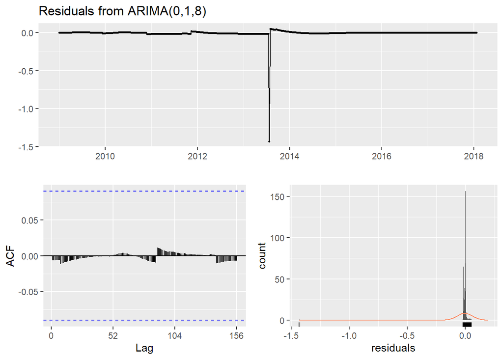

```
##
##  Ljung-Box test
##
## data:  Residuals from ARIMA(0,1,8)
## Q* = 1.4704, df = 86, p-value = 1
##
## Model df: 8.   Total lags used: 94
```

```r
checkresiduals(fit.test3)
```

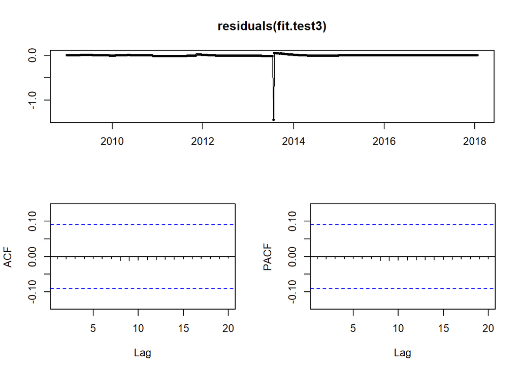

```r
tsdisplay(residuals(fit.test3), lag.max = 20)
```

try to predict data, using our model

```r
newdata2 <-forecast(fit.test3, h = 390, type="response")
```

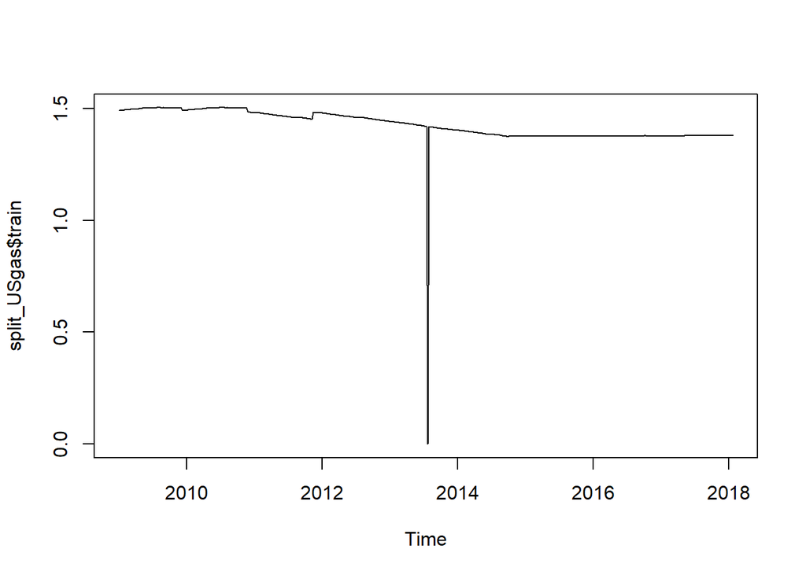

```r
plot(split_USgas$train)
```

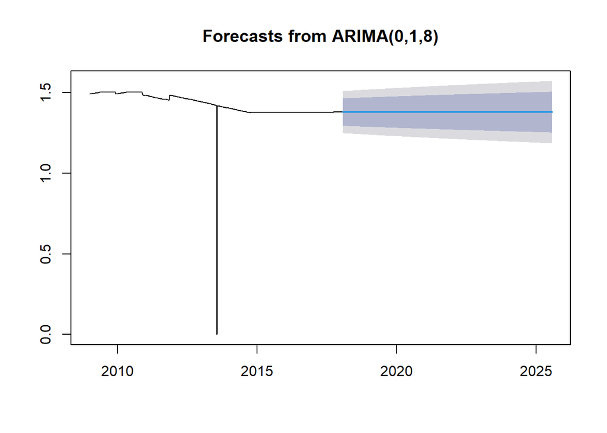

```r
plot(newdata2)
```

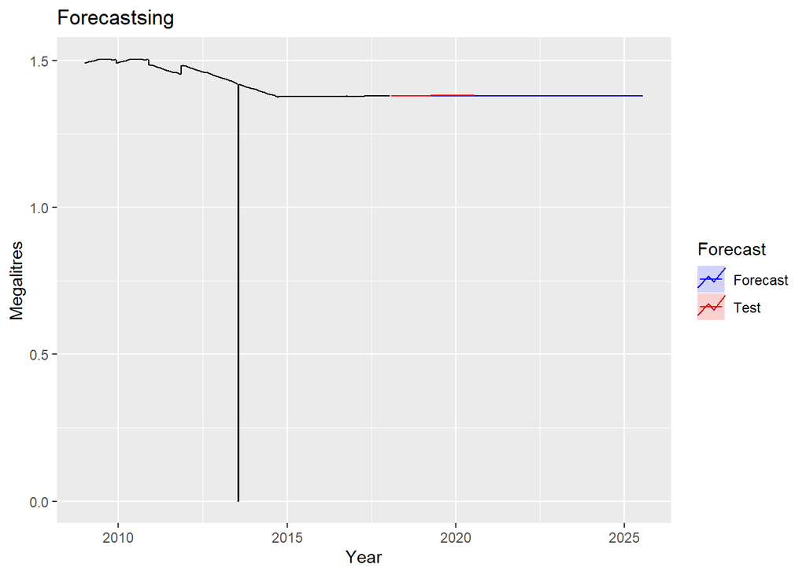

```r
clrs <- c("blue", "red")
autoplot(split_USgas$train) +
  autolayer(newdata2,
    series="Forecast", PI=FALSE) +
  autolayer(split_USgas$test,
    series="Test", PI=FALSE) +
  ggtitle("Forecastsing") +
  xlab("Year") + ylab("Megalitres") +
  guides(colour=guide_legend(title="Forecast"))+
      scale_color_manual(values=clrs)
```

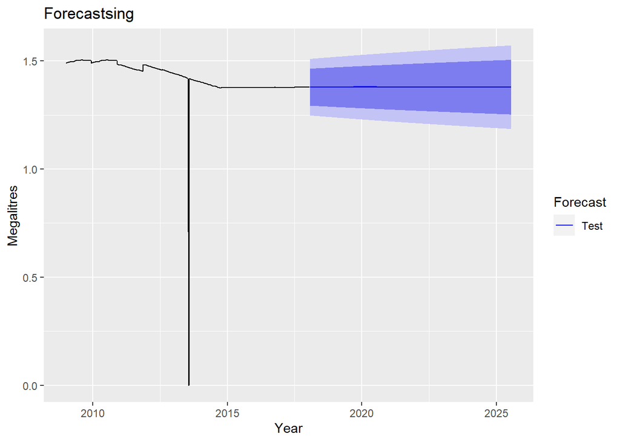

```r
autoplot(newdata2) +
  autolayer(split_USgas$test,
    series="Test", PI=FALSE) +
  ggtitle("Forecastsing") +
  xlab("Year") + ylab("Megalitres") +
  guides(colour=guide_legend(title="Forecast"))+
      scale_color_manual(values=clrs)
```

try to predict data, using forecast methods

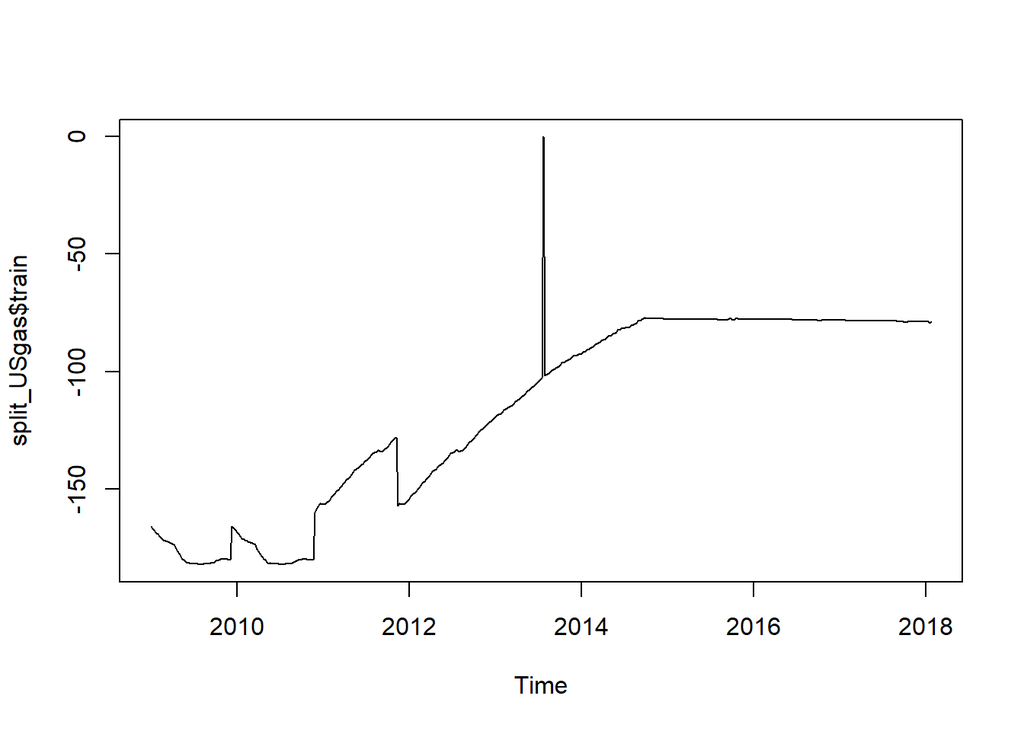

```r
library(TSstudio)
library(forecast)
split_USgas <- ts_split(ts.obj = myts, 130)

plot(split_USgas$train)
```

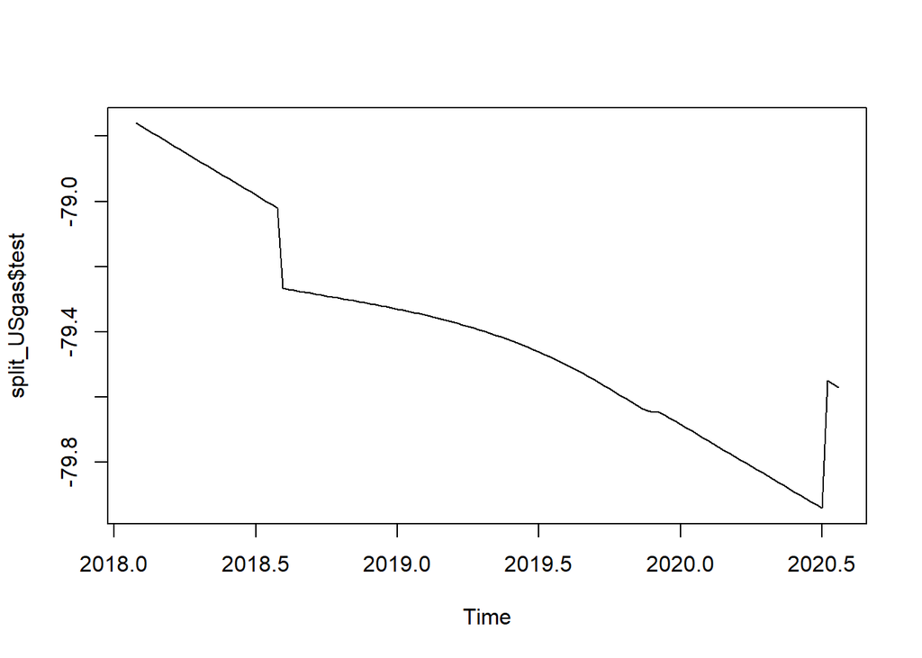

```r
plot(split_USgas$test)
```

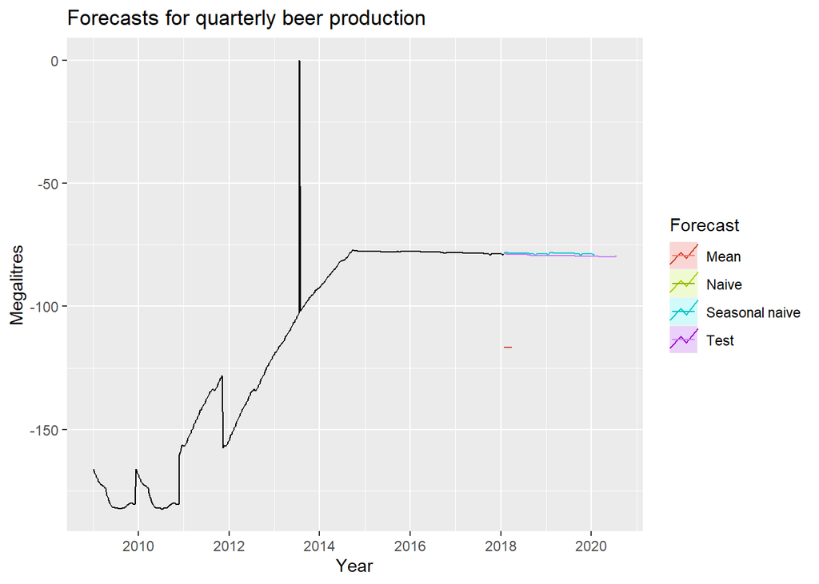

```r
autoplot(split_USgas$train) +
  autolayer(meanf(split_USgas$train),
    series="Mean", PI=FALSE) +
  autolayer(naive(split_USgas$train),
    series="Naïve", PI=FALSE) +
  autolayer(snaive(split_USgas$train),
    series="Seasonal naïve", PI=FALSE) +
   autolayer(split_USgas$test,
    series="Test", PI=FALSE)+
  ggtitle("Forecasts for quarterly beer production") +
  xlab("Year") + ylab("Megalitres") +
  guides(colour=guide_legend(title="Forecast"))
```

In the end we are doing a crossvalidation:

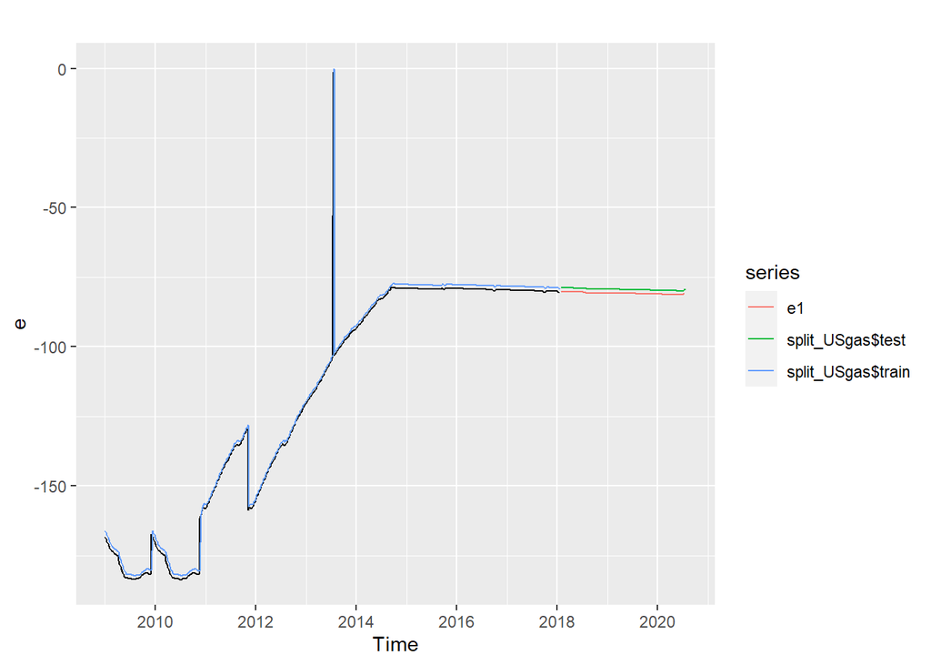

```r
#Fit an AR(2) model to each rolling origin subset
far2 <- function(x, h){forecast(fit.test4, h=h)}
#e <- tsCV(split_USgas$train, far2, h=1)
#plot(e)

#Fit the same model with a rolling window of length 30
e <- tsCV(split_USgas$train, far2, h=1)
e1 <- tsCV(split_USgas$test, far2, h=1)
autoplot(e) + autolayer(split_USgas$test) + autolayer(split_USgas$train) + autolayer(e1)
```